# hahow_R_programming_BA_HW3_AB_Testing

Yi-Chuan, Tsai

9/25/2021

## A/B 測試概念與個案實作練習

在這個章節的作業中，我們同樣利用「使用者購買行為」的資料集分析實驗設計的結果，了解影響消費者購買金額的重要變因，並探究哪個因素最能夠影響實驗結果。請使用uset_table.csv 與 test_table.csv 兩組資料集合(可於上一單元下載)，依照以下題目及步驟完成此次作業：

```r
test_table <- read_csv("L6_Dataset/test_table.csv")
user_table <- read_csv("L6_Dataset/user_table.csv")
```

## EDA:Clean and check the data before analysis

- Check table structure and view the data columns(test table):

```r
str(test_table)
```

```
## spec_tbl_df [100,000 × 5] (S3: spec_tbl_df/tbl_df/tbl/data.frame)
##  $ user_id        : num [1:100000] 1983 4704 14995 15089 17522 ...
##  $ date           : chr [1:100000] "2017/1/1" "2017/1/1" "2017/1/1" "2017/1/1" ...
##  $ device         : chr [1:100000] "pc_web" "android_app" "ios_app" "pc_web" ...
##  $ test           : num [1:100000] 0 1 0 0 0 1 0 0 0 1 ...
##  $ purchase_amount: num [1:100000] 33.7 30.2 37.2 49.8 19.7 33.6 45.1 12.2 34.4 55.9 ...
##  - attr(*, "spec")=
##   .. cols(
##   ..   user_id = col_double(),
##   ..   date = col_character(),
##   ..   device = col_character(),
##   ..   test = col_double(),
##   ..   purchase_amount = col_double()
##   .. )
```

```r
kable(test_table[1:5,])
```

| user_id | date | device | test | purchase_amount |
| --- | --- | --- | --- | --- |
| 1983 | 2017/1/1 | pc_web | 0 | 33.7 |
| 4704 | 2017/1/1 | android_app | 1 | 30.2 |
| 14995 | 2017/1/1 | ios_app | 0 | 37.2 |
| 15089 | 2017/1/1 | pc_web | 0 | 49.8 |
| 17522 | 2017/1/1 | pc_web | 0 | 19.7 |

- Check table structure and view the data columns(User table):

```r
str(user_table)
```

```
## spec_tbl_df [20,000 × 5] (S3: spec_tbl_df/tbl_df/tbl/data.frame)
##  $ user_id: num [1:20000] 1 2 3 4 5 6 7 8 9 10 ...
##  $ gender : chr [1:20000] "male" "male" "female" "male" ...
##  $ service: chr [1:20000] "golden" "premium" "premium" "golden" ...
##  $ age    : num [1:20000] 20 53 44 44 20 26 17 29 42 26 ...
##  $ country: chr [1:20000] "US" "US" "TW" "UK" ...
##  - attr(*, "spec")=
##   .. cols(
##   ..   user_id = col_double(),
##   ..   gender = col_character(),
##   ..   service = col_character(),
##   ..   age = col_double(),
##   ..   country = col_character()
##   .. )
```

```r
kable(user_table[1:5,])
```

| user_id | gender | service | age | country |
| --- | --- | --- | --- | --- |
| 1 | male | golden | 20 | US |
| 2 | male | premium | 53 | US |
| 3 | female | premium | 44 | TW |
| 4 | male | golden | 44 | UK |
| 5 | male | normal | 20 | US |

- Get the distinct count of users and check the overlap

```r
print(paste("Number of users in test table: ", length(unique(test_table$user_id))))
```

```
## [1] "Number of users in test table:  19871"
```

```r
print(paste("Number of users in user table: ", nrow(distinct(user_table, user_id))))
```

```
## [1] "Number of users in user table:  20000"
```

- If you select column and join then will have data tble issue

```r
print(paste('Number of users in both tables:', nrow(distinct(
    inner_join(select(test_table, user_id), select(user_table, user_id), by = 'user_id')
))))
```

```
## [1] "Number of users in both tables: 19871"
```

```r
all_table <- left_join(test_table, user_table, by = 'user_id')
head(all_table)
```

```
## # A tibble: 6 x 9
##   user_id date     device      test purchase_amount gender service   age country
##     <dbl> <chr>    <chr>      <dbl>           <dbl> <chr>  <chr>   <dbl> <chr>
## 1    1983 2017/1/1 pc_web         0            33.7 male   golden     37 US
## 2    4704 2017/1/1 android_a…     1            30.2 male   golden     33 UK
## 3   14995 2017/1/1 ios_app        0            37.2 male   golden     31 US
## 4   15089 2017/1/1 pc_web         0            49.8 male   golden     38 US
## 5   17522 2017/1/1 pc_web         0            19.7 male   normal     35 UK
## 6     186 2017/1/1 pc_web         1            33.6 female golden     50 BR
```

- Fix datatype

```r
all_table$date <- as.Date(all_table$date, format='%Y/%m/%d')

for(i in c(3, 4, 6, 7,9)){
    all_table[, i] <- as.factor(all_table[[i]])
}

str(all_table)
```

```
## spec_tbl_df [100,000 × 9] (S3: spec_tbl_df/tbl_df/tbl/data.frame)
##  $ user_id        : num [1:100000] 1983 4704 14995 15089 17522 ...
##  $ date           : Date[1:100000], format: "2017-01-01" "2017-01-01" ...
##  $ device         : Factor w/ 3 levels "android_app",..: 3 1 2 3 3 3 3 2 1 3 ...
##  $ test           : Factor w/ 2 levels "0","1": 1 2 1 1 1 2 1 1 1 2 ...
##  $ purchase_amount: num [1:100000] 33.7 30.2 37.2 49.8 19.7 33.6 45.1 12.2 34.4 55.9 ...
##  $ gender         : Factor w/ 2 levels "female","male": 2 2 2 2 2 1 1 1 1 2 ...
##  $ service        : Factor w/ 3 levels "golden","normal",..: 1 1 1 1 2 1 3 3 2 1 ...
##  $ age            : num [1:100000] 37 33 31 38 35 50 37 39 50 22 ...
##  $ country        : Factor w/ 5 levels "BR","JP","TW",..: 5 4 5 5 4 1 5 1 5 5 ...
##  - attr(*, "spec")=
##   .. cols(
##   ..   user_id = col_double(),
##   ..   date = col_character(),
##   ..   device = col_character(),
##   ..   test = col_double(),
##   ..   purchase_amount = col_double()
##   .. )
```

## Question 1:

篩選出屬於日本市場的使用者，針對購買金額進行獨立樣本 t 檢定。請問：實驗組的購買金額有沒有顯著高於對照組的購買金額？ 反之，針對購買金額進行獨立樣本 t 檢定，對照組金額有沒有顯著高於實驗組金額？ 請利用 ggplot2 繪製實驗組與對照組購買金額機率密度圖 (density plot)。

```r
jp_users <- all_table %>%
    filter(country =='JP')

print(head(jp_users))
```

```
## # A tibble: 6 x 9
##   user_id date       device   test  purchase_amount gender service   age country
##     <dbl> <date>     <fct>    <fct>           <dbl> <fct>  <fct>   <dbl> <fct>
## 1    4858 2017-01-01 android… 1                49.9 male   golden     14 JP
## 2   12858 2017-01-01 pc_web   1                40.2 male   premium    40 JP
## 3   16588 2017-01-01 pc_web   0                42.2 male   premium    18 JP
## 4    5997 2017-01-01 android… 0                41.3 male   premium    32 JP
## 5    4196 2017-01-01 pc_web   1                44.8 female premium    50 JP
## 6     680 2017-01-01 ios_app  1                28.5 male   premium    39 JP
```

- T -test for significance level : p-value = 1

```r
t.test(jp_users[jp_users$test==1,]$purchase_amount,
       jp_users[jp_users$test==0,]$purchase_amount,
       alternative = 'greater')
```

```
##
##  Welch Two Sample t-test
##
## data:  jp_users[jp_users$test == 1, ]$purchase_amount and jp_users[jp_users$test == 0, ]$purchase_amount
## t = -63.113, df = 9953.1, p-value = 1
## alternative hypothesis: true difference in means is greater than 0
## 95 percent confidence interval:
##  -9.297706       Inf
## sample estimates:
## mean of x mean of y
##  34.50391  43.56543
```

- ggplot for purchase amount density plot

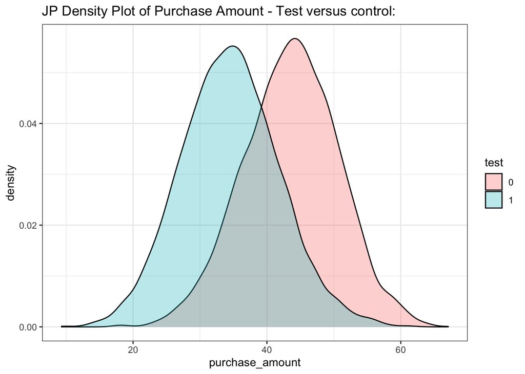

```r
ggplot(jp_users, aes(purchase_amount, fill = test)) +
    geom_density(alpha = 0.3) +
    ggtitle("JP Density Plot of Purchase Amount - Test versus control:") +
    theme_bw()
```

## Question 2:

建立購物金額與是否為實驗組、設備、性別與服務的變異數分析(ANOVA)模型。請問，模型中有哪些因子是顯著的？ - 請利用 ggplot2 繪製購買金額對應不同服務的盒狀圖 (boxplot)。 - 請進行 Tukey 事後檢定，了解 test 對於購買金額的影響，並繪製信賴區間圖形。 - 請進行 Tukey 事後檢定，了解 device 對於購買金額的影響，並繪製信賴區間圖形。

- Based on the result, test, device and service are sinigicant factors

```r
aov_model <- aov(
    purchase_amount ~ test + device + gender + service, all_table
)

summary(aov_model)
```

```
##                Df   Sum Sq Mean Sq   F value Pr(>F)
## test            1  1304220 1304220 11882.853 <2e-16 ***
## device          2   463996  231998  2113.752 <2e-16 ***
## gender          1      103     103     0.942  0.332
## service         2  1376036  688018  6268.585 <2e-16 ***
## Residuals   99993 10974881     110
## ---
## Signif. codes:  0 '***' 0.001 '**' 0.01 '*' 0.05 '.' 0.1 ' ' 1
```

- ggplot: service type

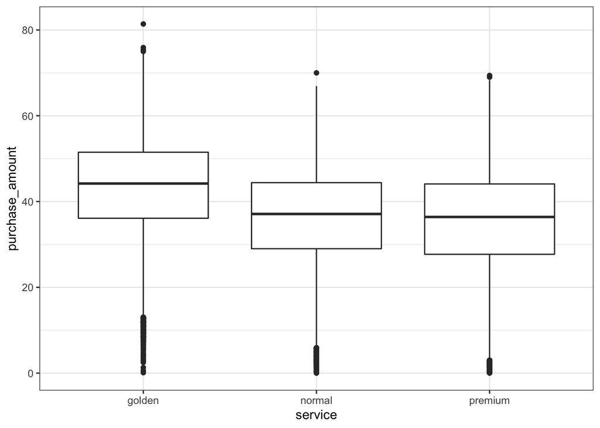

```r
ggplot(all_table, aes(x = service, y= purchase_amount)) +
    geom_boxplot() +
    theme_bw()
```

- Tukey 事後檢定，了解 test 對於購買金額的影響，並繪製信賴區間圖形。

```r
TukeyHSD(aov_model, 'test')
```

```
##   Tukey multiple comparisons of means
##     95% family-wise confidence level
##
## Fit: aov(formula = purchase_amount ~ test + device + gender + service, data = all_table)
##
## $test
##         diff      lwr      upr p adj
## 1-0 7.222798 7.092933 7.352663     0
```

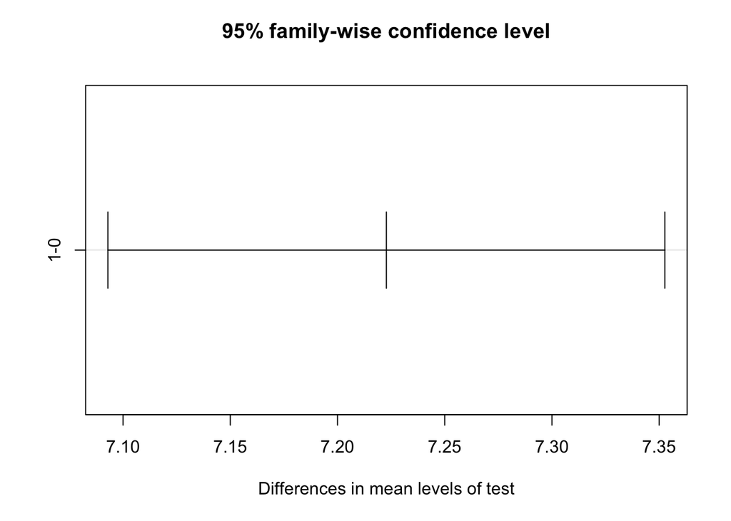

```r
plot(TukeyHSD(aov_model,'test'))
```

- Tukey 事後檢定，了解 device 對於購買金額的影響，並繪製信賴區間圖形。

```r
TukeyHSD(aov_model, 'device')
```

```
##   Tukey multiple comparisons of means
##     95% family-wise confidence level
##
## Fit: aov(formula = purchase_amount ~ test + device + gender + service, data = all_table)
##
## $device
##                          diff       lwr       upr p adj
## ios_app-android_app  5.881650  5.669637  6.093662     0
## pc_web-android_app   3.913586  3.701622  4.125549     0
## pc_web-ios_app      -1.968064 -2.141917 -1.794211     0
```

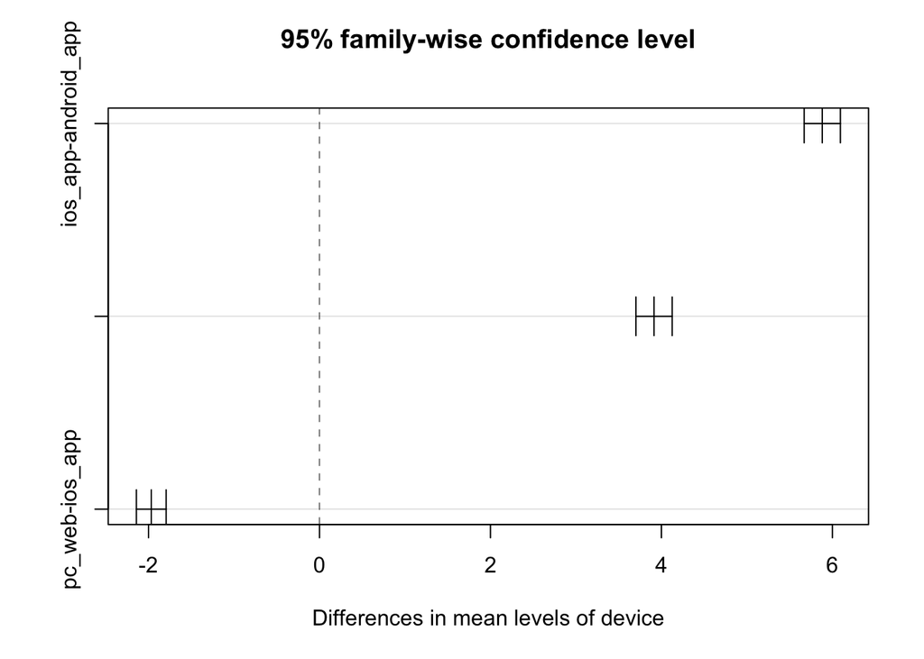

```r
plot(TukeyHSD(aov_model,'device'))
```